*DAIA - Week 4 Assignment*

# Missing data in the Titanic dataset

## 1. Introduction

In this titanic example we will focus on how to find, label and deal with missing data. Make sure you have studies the study materials in Canvas about the various types of missing data and how to handle these kind of missing data.

Each instance in the dataset has the following form:

```
 "1","1st",1,"Allen, Miss Elisabeth Walton",29.0000,"Southampton","St Louis, MO","B-5","24160 L221","2","female"
```

Note that the raw data consists largely of strings. To apply machine learning algo's these strings have to be converted to numerical data first (at least the columns that are of interest)!

## 2. Data collection

Pandas is a Python module that works with the so-called dataframe concept (rows are observations, columns refer to the features). A dataframe is essentially a two-dimensional labeled data structure where each column represent a feature and each row represents an observation.

More details, see: https://www.kaggle.com/c/titanic/details/getting-started-with-python-ii

### 2.1. Load Dataset

Download the Titanic dataset (csv file) from Canvas, read it with Pandas into a dataframe. Show the first 5 rows.

```python
import pandas as pd
import numpy as np

print('numpy version:', np.__version__)
print('matplotlib version:', pd.__version__)

## To get you started...
df_titanic = pd.read_csv("C:/titanic-main/Titanic.csv")
df_titanic.columns =['passengers','pclass','survived','name','age','embarked','home/dest','room','ticket','boat','sex']
df_titanic.head(5)
```

```
numpy version: 1.24.0
matplotlib version: 2.1.0
```

|  | passengers | pclass | survived | name | age | embarked | home/dest | room | ticket | boat | sex |
| --- | --- | --- | --- | --- | --- | --- | --- | --- | --- | --- | --- |
| 0 | 1 | 1st | 1 | Allen, Miss Elisabeth Walton | 29.0000 | Southampton | St Louis, MO | B-5 | 24160 L221 | 2 | female |
| 1 | 2 | 1st | 0 | Allison, Miss Helen Loraine | 2.0000 | Southampton | Montreal, PQ / Chesterville, ON | C26 | NaN | NaN | female |
| 2 | 3 | 1st | 0 | Allison, Mr Hudson Joshua Creighton | 30.0000 | Southampton | Montreal, PQ / Chesterville, ON | C26 | NaN | -135 | male |
| 3 | 4 | 1st | 0 | Allison, Mrs Hudson J.C. (Bessie Waldo Daniels) | 25.0000 | Southampton | Montreal, PQ / Chesterville, ON | C26 | NaN | NaN | female |
| 4 | 5 | 1st | 1 | Allison, Master Hudson Trevor | 0.9167 | Southampton | Montreal, PQ / Chesterville, ON | C22 | NaN | 11 | male |

## 3. Data understanding

You can examine the datatypes and some general (statistical) information about the dataset. See if you can already see something odd or striking, which indicates missing data.

```python
df_titanic.dtypes

## Why is it good to first check the datatypes, before examining the columns or values for missing data?
## Your answer (and explanation):
## Knowing the data types can help you choose the right way to handle the missing data. Numerical data should be handled differently than categorical data.
```

```
passengers      int64
pclass         object
survived        int64
name           object
age           float64
embarked       object
home/dest      object
room           object
ticket         object
boat           object
sex            object
dtype: object
```

Which columns contain missing values? You should find at least 3 (4 is better ;) ).

```python
## Your code and comments here...
df_titanic.isnull().sum()
```

```
passengers       0
pclass           0
survived         0
name             0
age            680
embarked       492
home/dest      559
room          1236
ticket        1244
boat           966
sex              0
dtype: int64
```

Next step is to examine and explain *why* these values are missing. Remember MCAR, MAR, M(C)NAR... Don't forget to use visualization (histograms might be useful) as well to investigate or explain this.

# Age

```python
import pandas as pd

# Filter rows where "age" is missing (contains NaN)
missing_age_rows = df_titanic[df_titanic['age'].isna()]

# Display the rows with missing age data
print(missing_age_rows)
```

```
      passengers pclass  survived                          name  age  \
12            13    1st         1  Aubert, Mrs Leontine Pauline  NaN
13            14    1st         1     Barkworth, Mr Algernon H.  NaN
14            15    1st         0           Baumann, Mr John D.  NaN
29            30    1st         0       Borebank, Mr John James  NaN
32            33    1st         1            Bradley, Mr George  NaN
...          ...    ...       ...                           ...  ...
1308        1309    3rd         0            Zakarian, Mr Artun  NaN
1309        1310    3rd         0        Zakarian, Mr Maprieder  NaN
1310        1311    3rd         0               Zenn, Mr Philip  NaN
1311        1312    3rd         0                 Zievens, Rene  NaN
1312        1313    3rd         0                Zimmerman, Leo  NaN

         embarked              home/dest    room        ticket boat     sex
12      Cherbourg          Paris, France    B-35  17477 L69 6s    9  female
13    Southampton          Hessle, Yorks    A-23           NaN    B    male
14    Southampton           New York, NY     NaN           NaN  NaN    male
29    Southampton  London / Winnipeg, MB  D-21/2           NaN  NaN    male
32    Southampton        Los Angeles, CA     NaN           NaN   15    male
...           ...                    ...     ...           ...  ...     ...
1308          NaN                    NaN     NaN           NaN  NaN    male
1309          NaN                    NaN     NaN           NaN  NaN    male
1310          NaN                    NaN     NaN           NaN  NaN    male
1311          NaN                    NaN     NaN           NaN  NaN  female
1312          NaN                    NaN     NaN           NaN  NaN    male

[680 rows x 11 columns]
```

```
survived
0    512
1    168
Name: count, dtype: int64
Not Survived: 512
```

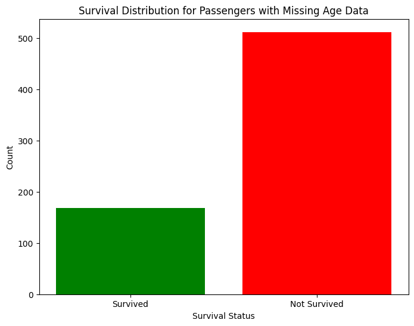

```python
import pandas as pd
import matplotlib.pyplot as plt


# Filter rows where "age" is missing (contains NaN)
missing_age_rows = df_titanic[df_titanic['age'].isna()]

# Count the number of passengers who survived and did not survive among those with missing age data
survived_count = missing_age_rows[missing_age_rows['survived'] == 1].shape[0]
not_survived_count = missing_age_rows[missing_age_rows['survived'] == 0].shape[0]

# Print the counts for troubleshooting
print(missing_age_rows['survived'].value_counts())

print("Not Survived:", not_survived_count)

# Create a bar plot to visualize the survival distribution
plt.figure(figsize=(8, 6))
plt.bar(['Survived', 'Not Survived'], [survived_count, not_survived_count], color=['green', 'red'])
plt.xlabel("Survival Status")
plt.ylabel("Count")
plt.title("Survival Distribution for Passengers with Missing Age Data")
plt.show()
```

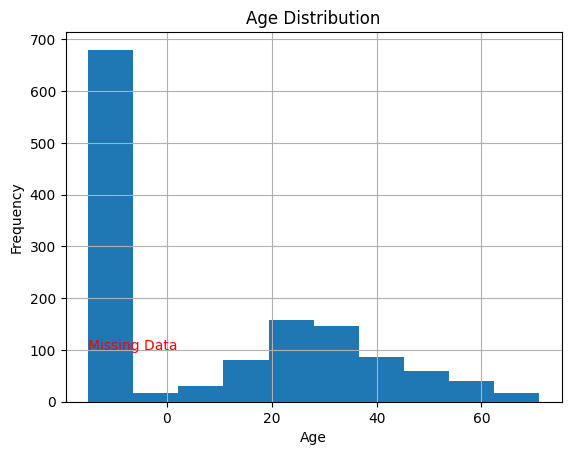

```python
## Your code and comments....
import pandas as pd
import matplotlib.pyplot as plt

df_titanic['age'].fillna(-15, inplace=True)  # Fill missing age values with -1

df_titanic['age'].hist()

plt.xlabel("Age")
plt.ylabel("Frequency")
plt.title("Age Distribution")
plt.annotate('Missing Data', xy=(-15,100), color='red')

plt.show()
```

## Explanation

First I wanted to check if all of the people with the missing age data also did not survive. However, this was not the case. I would say this is MCAR, the data was simply lost, maybe because everything was kept on paper and not yet digitally.

# Embarked

```python
import pandas as pd

# Filter rows where "age" is missing (contains NaN)
missing_embarked_rows = df_titanic[df_titanic['embarked'].isna()]

# Display the rows with missing age data
print(missing_embarked_rows)
```

```
      passengers pclass  survived                            name   age  \
62            63    1st         0    Chisholm, Mr Roderick Robert -15.0
165          166    1st         0              Lingrey, Mr Edward -15.0
195          196    1st         0  Ovies y Rodriguez, Mr Servando  28.0
196          197    1st         0    Parr, Mr William Henry Marsh -15.0
229          230    1st         0        Silvey, Mr William Baird  50.0
...          ...    ...       ...                             ...   ...
1308        1309    3rd         0              Zakarian, Mr Artun -15.0
1309        1310    3rd         0          Zakarian, Mr Maprieder -15.0
1310        1311    3rd         0                 Zenn, Mr Philip -15.0
1311        1312    3rd         0                   Zievens, Rene -15.0
1312        1313    3rd         0                  Zimmerman, Leo -15.0

     embarked                     home/dest room ticket  boat     sex
62        NaN  Liverpool, England / Belfast  NaN    NaN   NaN    male
165       NaN                           NaN  NaN    NaN   NaN    male
195       NaN                 ?Havana, Cuba  NaN    NaN  -189    male
196       NaN                       Belfast  NaN    NaN   NaN    male
229       NaN                    Duluth, MN  NaN    NaN   NaN    male
...       ...                           ...  ...    ...   ...     ...
1308      NaN                           NaN  NaN    NaN   NaN    male
1309      NaN                           NaN  NaN    NaN   NaN    male
1310      NaN                           NaN  NaN    NaN   NaN    male
1311      NaN                           NaN  NaN    NaN   NaN  female
1312      NaN                           NaN  NaN    NaN   NaN    male

[492 rows x 11 columns]
```

```
survived
0    405
1     87
Name: count, dtype: int64
Not Survived: 405
```

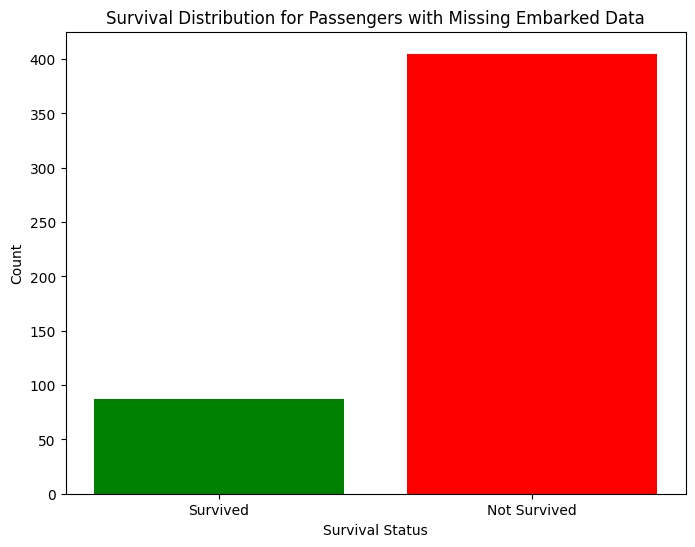

```python
import pandas as pd
import matplotlib.pyplot as plt


# Filter rows where "age" is missing (contains NaN)
missing_embarked_rows = df_titanic[df_titanic['embarked'].isna()]

# Count the number of passengers who survived and did not survive among those with missing age data
survived_count = missing_embarked_rows[missing_embarked_rows['survived'] == 1].shape[0]
not_survived_count = missing_embarked_rows[missing_embarked_rows['survived'] == 0].shape[0]

# Print the counts for troubleshooting
print(missing_embarked_rows['survived'].value_counts())

print("Not Survived:", not_survived_count)

# Create a bar plot to visualize the survival distribution
plt.figure(figsize=(8, 6))
plt.bar(['Survived', 'Not Survived'], [survived_count, not_survived_count], color=['green', 'red'])
plt.xlabel("Survival Status")
plt.ylabel("Count")
plt.title("Survival Distribution for Passengers with Missing Embarked Data")
plt.show()
```

```python
missing_embarked_rows = df_titanic[df_titanic['embarked'].isna()]

print("Number of missing 'embarked' values:", len(missing_embarked_rows))

missing_features = missing_embarked_rows[['passengers', 'pclass', 'survived', 'name', 'age', 'home/dest', 'room', 'ticket', 'boat', 'sex']].isna().sum()

print("Number of times other features are missing in these rows:")
print(missing_features)
```

```
Number of missing 'embarked' values: 492
Number of times other features are missing in these rows:
passengers      0
pclass          0
survived        0
name            0
age             0
home/dest     478
room          492
ticket        492
boat          488
sex             0
dtype: int64
```

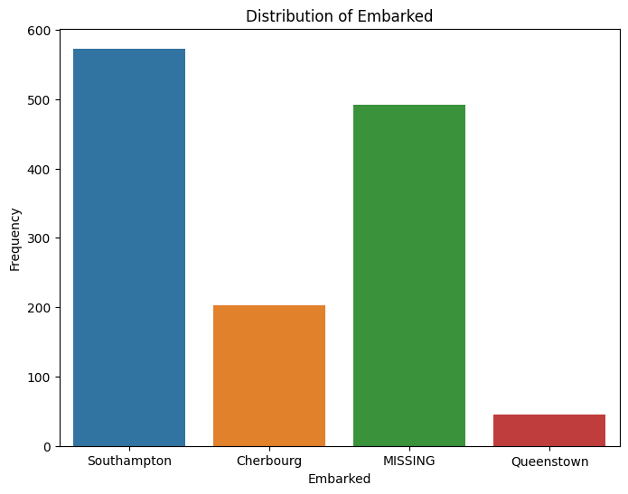

```python
import matplotlib.pyplot as plt
import seaborn as sns

# Assuming df_titanic contains your Titanic dataset

# Fill missing 'embarked' values with a placeholder (e.g., "-15")
df_titanic['embarked'].fillna("MISSING", inplace=True)

# Create a count plot for 'embarked'
plt.figure(figsize=(8, 6))
sns.countplot(x='embarked', data=df_titanic)
plt.xlabel("Embarked")
plt.ylabel("Frequency")
plt.title("Distribution of Embarked")
plt.show()
```

## Explanation

I think the same explanation to age holds up here. It's not the case that all of the missing data could be explained because of their death, because some of the people with missing data did survive. However, there is a correlation between Embarked, Room and Ticket (and possibly home/dest and Boat). Everywhere where Embarked is missing, the data of Room and Ticket is also missing. I would say this is also MCAR. I think it is because of the same reasoning as for age.

# Boat

```python
import pandas as pd

# Filter rows where "age" is missing (contains NaN)
missing_boat_rows = df_titanic[df_titanic['boat'].isna()]

# Display the rows with missing age data
print(missing_boat_rows)
```

```
      passengers pclass  survived  \
1              2    1st         0
3              4    1st         0
7              8    1st         0
14            15    1st         0
16            17    1st         0
...          ...    ...       ...
1308        1309    3rd         0
1309        1310    3rd         0
1310        1311    3rd         0
1311        1312    3rd         0
1312        1313    3rd         0

                                                 name   age     embarked  \
1                         Allison, Miss Helen Loraine   2.0  Southampton
```

[output cut: 25 more lines]

```
survived
0    785
1    181
Name: count, dtype: int64
Not Survived: 785
```

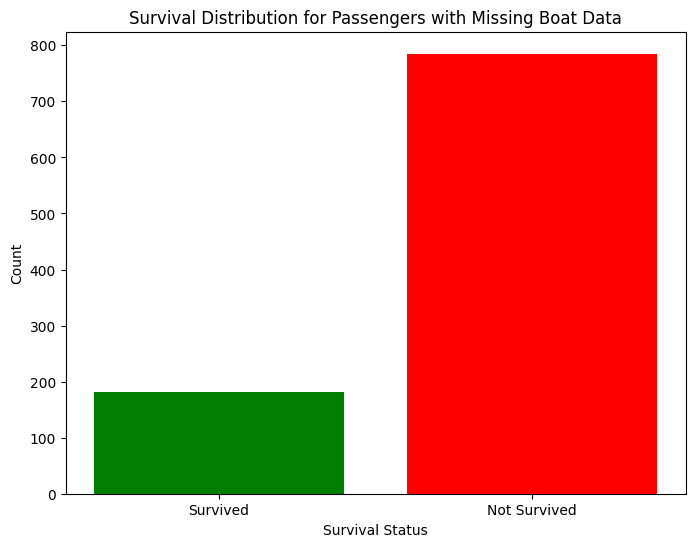

```python
import pandas as pd
import matplotlib.pyplot as plt


# Filter rows where "age" is missing (contains NaN)
missing_boat_rows = df_titanic[df_titanic['boat'].isna()]

# Count the number of passengers who survived and did not survive among those with missing age data
survived_count = missing_boat_rows[missing_boat_rows['survived'] == 1].shape[0]
not_survived_count = missing_boat_rows[missing_boat_rows['survived'] == 0].shape[0]

# Print the counts for troubleshooting
print(missing_boat_rows['survived'].value_counts())

print("Not Survived:", not_survived_count)

# Create a bar plot to visualize the survival distribution
plt.figure(figsize=(8, 6))
plt.bar(['Survived', 'Not Survived'], [survived_count, not_survived_count], color=['green', 'red'])
plt.xlabel("Survival Status")
plt.ylabel("Count")
plt.title("Survival Distribution for Passengers with Missing Boat Data")
plt.show()
```

```python
missing_boat_rows = df_titanic[df_titanic['boat'].isna()]

print("Number of missing 'embarked' values:", len(missing_boat_rows))

missing_features = missing_boat_rows[['passengers', 'pclass', 'survived', 'name', 'age', 'home/dest', 'room', 'ticket', 'boat', 'sex']].isna().sum()

print("Number of times other features are missing in these rows:")
print(missing_features)
```

```
Number of missing 'embarked' values: 966
Number of times other features are missing in these rows:
passengers      0
pclass          0
survived        0
name            0
age             0
home/dest     546
room          945
ticket        947
boat          966
sex             0
dtype: int64
```

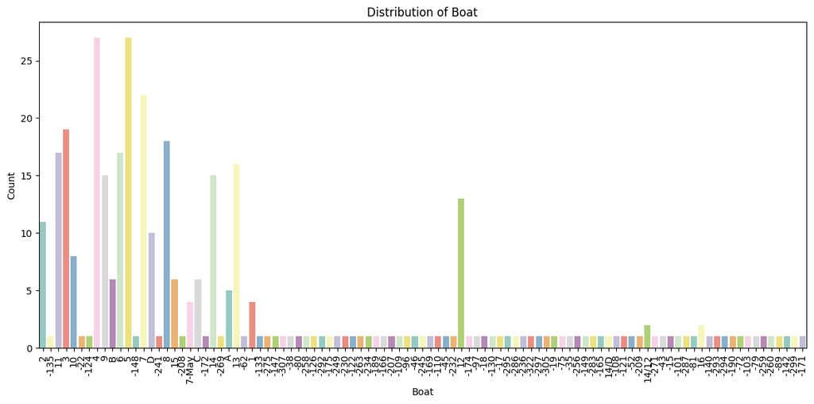

```python
import matplotlib.pyplot as plt
import seaborn as sns

# Create a count plot for 'boat' with better readability
plt.figure(figsize=(12, 6))
sns.countplot(x='boat', data=df_titanic, palette='Set3')  # Use a different color palette for better visualization
plt.xlabel("Boat")
plt.ylabel("Count")
plt.title("Distribution of Boat")
plt.xticks(rotation=90)  # Rotate x-axis labels for better readability
plt.tight_layout()  # Adjust layout to prevent label cutoff
plt.show()
```

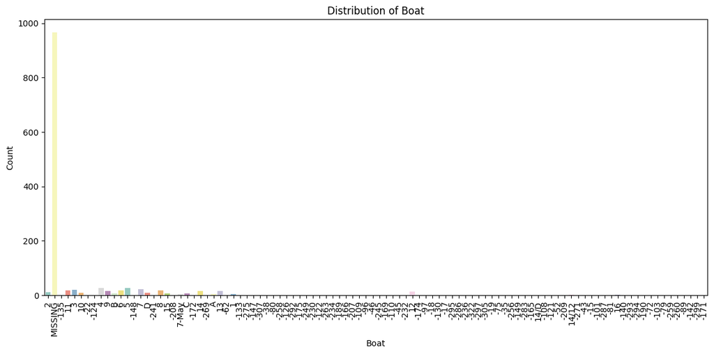

```python
import matplotlib.pyplot as plt
import seaborn as sns

# Fill missing 'boat' values with a placeholder (e.g., "MISSING")
df_titanic['boat'].fillna("MISSING", inplace=True)

# Create a count plot for 'boat' with better readability
plt.figure(figsize=(12, 6))
sns.countplot(x='boat', data=df_titanic, palette='Set3')  # Use a different color palette for better visualization
plt.xlabel("Boat")
plt.ylabel("Count")
plt.title("Distribution of Boat")
plt.xticks(rotation=90)  # Rotate x-axis labels for better readability
plt.tight_layout()  # Adjust layout to prevent label cutoff
plt.show()
```

## 4. Data Preparation

### 4.1. Deal with Missing Values

You have found some (indications, clues for) missing data. Under 'Data Understanding' you have looked for reasons why and perhaps also found some relationships with other values or features. That helps you to 'label' the type of missing data. Now it's time to deal with the missing values. It could be a requirement of the machine learning model that it needs a complete set of values for a feature. There are several options as you know. Deleting rows can reduce missing values, but it also reduces the total amount of data... Another way is to fill it in with guesses. You will be introducing some noise into a model, but if you canmake reasonable guesses, some of them should be close to the historical truth (whatever it was...), and the overall predictive power of the model might still make a better model than before.

#### Look at the features with missing data and explain and apply a suitable method to deal with these missing values...

## Resetting the dataset

Because I changed some values in the graphs to visualize the missing values, the data was incorrect. So I decided to reset the dataset by just reading it again.

```python
df_titanic = pd.read_csv("C:/titanic-main/Titanic.csv")
df_titanic.columns =['passengers','pclass','survived','name','age','embarked','home/dest','room','ticket','boat','sex']
```

## Age

I think for age, the best solution will be filling the missing values with the mean value. This will affect the average the least.

```python
mean_age = df_titanic['age'].mean()
df_titanic['age'].fillna(mean_age, inplace=True)


print(df_titanic['age'].mean())
```

```
31.19418104265403
```

# Embarked

For embarked it is a bit more complicated in my opinion. We can say we impute the value of the most occuring place, but this would significantly shift the average since we got a lot of missing values. The other option would be to remove the rows all together. I think both are not the best options, but if I had to choose i would go for the first one; impute the value of the most occuring place.

```python
most_common_embarked = df_titanic['embarked'].mode()[0]
df_titanic['embarked'].fillna(most_common_embarked, inplace=True)
print(df_titanic['embarked'].mode())
```

```
0    Southampton
Name: embarked, dtype: object
```

# Boat

For boat it is yet another case. I think the boats mean the rescue boats. In this case, the people on board should be evenly distributed over the boats.

```python
import pandas as pd
import random

# Calculate the number of missing values and the number of unique 'boat' categories
missing_count = df_titanic['boat'].isnull().sum()
unique_boats = df_titanic['boat'].nunique()

# Determine how many missing values should be imputed for each 'boat' category
impute_per_category = missing_count // unique_boats

# Create a DataFrame with missing 'boat' values
missing_boat_df = df_titanic[df_titanic['boat'].isna()]

# Initialize an empty list to store the imputed 'boat' values
imputed_boats = []

# Iterate over unique 'boat' categories
for boat_category in df_titanic['boat'].unique():
    # Check if there are any missing values in the 'boat' column for this category
    if missing_boat_df[missing_boat_df['boat'].isna()].empty:
        continue

    # Select 'impute_per_category' random rows for this 'boat' category
    random_rows = missing_boat_df.sample(impute_per_category, random_state=42)

    # Assign the 'boat' category to the selected rows
    random_rows['boat'] = boat_category

    # Add the selected rows to the list of imputed 'boat' values
    imputed_boats.append(random_rows)

# Concatenate the imputed 'boat' values back to the original DataFrame
imputed_df = pd.concat([df_titanic, *imputed_boats], ignore_index=True)

imputed_df
```

|  | passengers | pclass | survived | name | age | embarked | home/dest | room | ticket | boat | sex |
| --- | --- | --- | --- | --- | --- | --- | --- | --- | --- | --- | --- |
| 0 | 1 | 1st | 1 | Allen, Miss Elisabeth Walton | 29.000000 | Southampton | St Louis, MO | B-5 | 24160 L221 | 2 | female |
| 1 | 2 | 1st | 0 | Allison, Miss Helen Loraine | 2.000000 | Southampton | Montreal, PQ / Chesterville, ON | C26 | NaN | NaN | female |
| 2 | 3 | 1st | 0 | Allison, Mr Hudson Joshua Creighton | 30.000000 | Southampton | Montreal, PQ / Chesterville, ON | C26 | NaN | -135 | male |
| 3 | 4 | 1st | 0 | Allison, Mrs Hudson J.C. (Bessie Waldo Daniels) | 25.000000 | Southampton | Montreal, PQ / Chesterville, ON | C26 | NaN | NaN | female |
| 4 | 5 | 1st | 1 | Allison, Master Hudson Trevor | 0.916700 | Southampton | Montreal, PQ / Chesterville, ON | C22 | NaN | 11 | male |
| ... | ... | ... | ... | ... | ... | ... | ... | ... | ... | ... | ... |
| 2208 | 251 | 1st | 0 | Stewart, Mr Albert A. | 31.194181 | Cherbourg | Gallipolis, Ohio / ? Paris / New York | NaN | NaN | -171 | male |
| 2209 | 636 | 3rd | 0 | Angheloff, Mr Minko | 26.000000 | Southampton | Bulgaria Chicago, IL | NaN | NaN | -171 | male |
| 2210 | 1269 | 3rd | 0 | Van Billiard, Master Walter John | 31.194181 | Southampton | NaN | NaN | NaN | -171 | male |
| 2211 | 1135 | 3rd | 0 | Pettersson, Miss Ellen Natalia | 31.194181 | Southampton | NaN | NaN | NaN | -171 | female |
| 2212 | 291 | 1st | 1 | Bazzani, Ms Albina | 31.194181 | Cherbourg | NaN | NaN | NaN | -171 | female |

2213 rows × 11 columns